# CM 3015 Machine Learning and Neural Networks Final

```python
#importing libraries

pip install -q tfds-nightly tensorflow matplotlib
```

```python
import matplotlib.pyplot as plt
import numpy as np
import tensorflow as tf

import tensorflow_datasets as tfds
```

```python
from tensorflow.keras.datasets import fashion_mnist
from sklearn.model_selection import train_test_split
from tensorflow.keras import models, layers
from tensorflow.keras import regularizers
from sklearn.metrics import confusion_matrix, precision_score, recall_score, f1_score, cohen_kappa_score
from tensorflow.keras.callbacks import ReduceLROnPlateau, EarlyStopping
```

## 1. Introduction

The universal machine learning workflow mentioned in the Chollet's Deep Learning with python will be explored in this report

## 2. Defining the Problem

Fashion MNIST dataset consists of 28x28 grayscale images of fashion items such as t-shirts, trousers, dresses, and shoes, among others. Each image is assigned a label indicating the type of clothing it represents. The dataset contains 10 classes in total.

Therefore, the problem can be framed as follows:

Given a dataset of grayscale images of fashion items and their corresponding labels, the task is to develop a machine learning model that can accurately predict the class label of a given image, thereby effectively categorizing the clothing items depicted in the images.

## 3. Choosing a measure of success

We will be using Precision, recall, F1 Score and Cohen Kappa to evaluate the models

## 4. Deciding on an evaluation protocol

In most cases, hold out validation is sufficent. So the model will be using hold out as a the choosen evaluation protocol.

## 5. Preparing you data

### MNIST Data Sample

[output not shown]

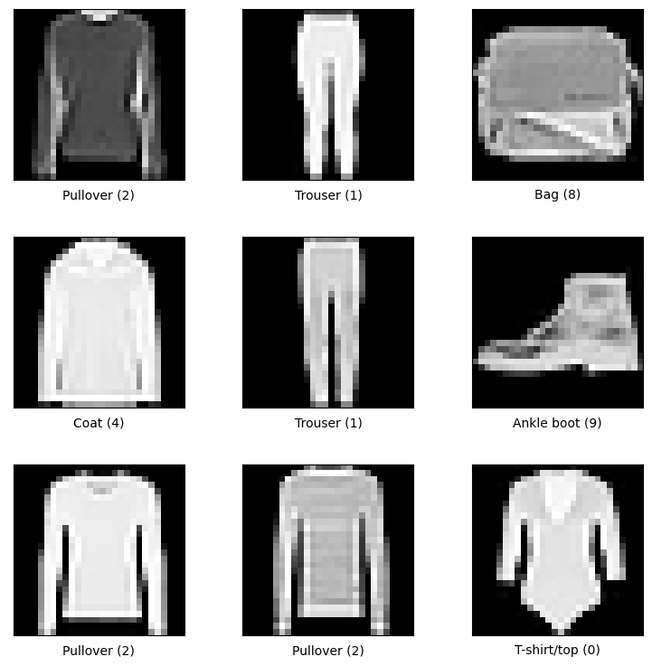

```python
dataset, ds_info = tfds.load('fashion_mnist', split = 'train', with_info = True)
fig = tfds.show_examples(dataset,ds_info)
```

```python
#Seperatng dataset into validation/ test and train sets

data_size = 70000
train_ratio = 0.7
valid_ratio = 0.2
test_ratio = 0.3

(x_train, y_train), (x_test, y_test) = fashion_mnist.load_data()

X = np.concatenate([x_train ,x_test])
Y = np.concatenate([y_train ,y_test])

X_train, X_val, y_train, y_val = train_test_split(X, Y, test_size = (1-train_ratio),random_state = 42)
X_val, X_test, y_val, y_test = train_test_split(X_val, y_val, test_size = (test_ratio /(valid_ratio + test_ratio)), random_state = 42)
```

```python
#find the shape of split dataset

print('fm_train_img', X_train.shape)
print('fm_train_labels', y_train.shape)
print('fm_val_img', X_val.shape)
print('fm_val_labels', y_val.shape)
print('fm_test_img', X_test.shape)
print('fm_test_labels', y_test.shape)
```

```
fm_train_img (48999, 28, 28)
fm_train_labels (48999,)
fm_val_img (8400, 28, 28)
fm_val_labels (8400,)
fm_test_img (12601, 28, 28)
fm_test_labels (12601,)
```

## Baseline

```python
#show the number of the number of samples per label/class

totals_train = np.zeros(10)
totals_test = np.zeros(10)

total_y_train = np.concatenate([y_train, y_val])

for i in range(len(total_y_train)):
    totals_train[total_y_train[i]] += 1

for i in range(len(y_test)):
    totals_test[y_test[i]] += 1

index = np.argmax(totals_train)
hits = totals_test[index]
hit_rate = hits / np.sum(y_test)
```

```python
#reshape data

X_train = X_train.reshape(48999, 28 * 28)
X_test = X_test.reshape(12601, 28 * 28)
X_val = X_val.reshape(8400, 28 * 28)
```

```python
#cast as float and rescale

X_train = X_train.astype('float32')/ 255
X_test = X_test.astype('float32')/ 255
X_val = X_val.astype('float32') /255
```

```python
#encode the categorical function

from tensorflow.keras.utils import to_categorical

y_train = to_categorical(y_train)
y_test = to_categorical(y_test)
y_val = to_categorical(y_val)
```

```python
#print shape of data

print('fm_train_img', X_train.shape)
print('fm_train_labels', y_train.shape)
print('fm_val_img', X_val.shape)
print('fm_val_labels', y_train.shape)
print('fm_test_img', X_test.shape)
print('fm_test_labels', y_test.shape)
```

```
fm_train_img (48999, 784)
fm_train_labels (48999, 10)
fm_val_img (8400, 784)
fm_val_labels (48999, 10)
fm_test_img (12601, 784)
fm_test_labels (12601, 10)
```

```python
#write function that will plot loss and accuracy graphs

def plot_loss(loss, val_loss):
    plt.clf()
    epochs = range(1, len(loss) + 1)
    plt.plot(epochs, loss, 'bo', label = "Loss")
    plt.plot(epochs, val_loss, 'b', label = "validation loss")
    plt.title('Training loss and validation loss')
    plt.xlabel('Epochs')
    plt.ylabel('Loss')
    plt.legend()
    plt.show()
```

```python
def plot_accuracy(acc, val_acc):
    plt.clf()
    epochs = range(1, len(acc) + 1)
    plt.plot(epochs, acc, 'bo', label = "Accuracy")
    plt.plot(epochs, val_acc, 'b', label = "Validation accuracy")
    plt.title('Training and validation accuracy')
    plt.xlabel('Epochs')
    plt.ylabel('Accuracy')
    plt.legend()
    plt.show()
```

```python
#building the model

base_model = models.Sequential()
```

```python
base_model.add(layers.Dense(10, activation = 'softmax'))
```

```python
base_model.compile(optimizer = 'adam', loss='categorical_crossentropy', metrics=['accuracy'])
```

```python
results1 = underfit_model.fit(X_train, y_train, epochs = 10, batch_size = 128, validation_data=(X_val, y_val))
```

```python
base_model.summary()
```

```
Model: "sequential_7"
_________________________________________________________________
 Layer (type)                Output Shape              Param #
=================================================================
 dense_23 (Dense)            (None, 10)                7850

=================================================================
Total params: 7850 (30.66 KB)
Trainable params: 7850 (30.66 KB)
Non-trainable params: 0 (0.00 Byte)
_________________________________________________________________
```

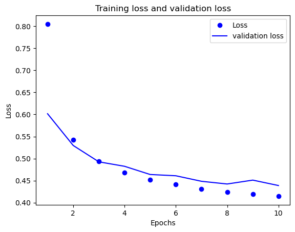

```python
plot_loss(results1.history['loss'], results1.history['val_loss'])
```

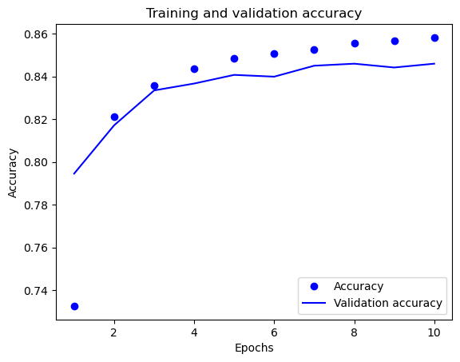

```python
plot_accuracy(results1.history['accuracy'], results1.history['val_accuracy'])
```

```python
test_loss, test_acc = base_model.evaluate(X_val, y_val)
```

## Overfit model

```python
#build the model

overfit_network = models.Sequential()
```

```python
overfit_network.add(layers.Dense(512, activation='relu', input_shape=(28 * 28,)))
overfit_network.add(layers.Dense(124, activation = 'relu'))
overfit_network.add(layers.Dense(46, activation = 'relu'))
overfit_network.add(layers.Dense(10, activation = 'softmax'))
```

```python
overfit_network.compile(optimizer='rmsprop',
                loss='categorical_crossentropy',
                metrics=['accuracy'])
```

```python
results2 = overfit_network.fit(X_train, y_train, epochs=40, batch_size=64, validation_data=(X_val, y_val))
```

```python
overfit_network.summary()
```

```
Model: "sequential_8"
_________________________________________________________________
 Layer (type)                Output Shape              Param #
=================================================================
 dense_24 (Dense)            (None, 512)               401920

 dense_25 (Dense)            (None, 124)               63612

 dense_26 (Dense)            (None, 46)                5750

 dense_27 (Dense)            (None, 10)                470

=================================================================
Total params: 471752 (1.80 MB)
Trainable params: 471752 (1.80 MB)
Non-trainable params: 0 (0.00 Byte)
_________________________________________________________________
```

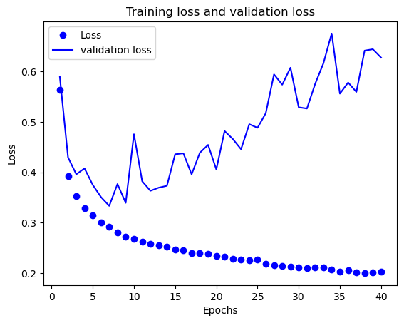

```python
plot_loss(results2.history['loss'], results2.history['val_loss'])
```

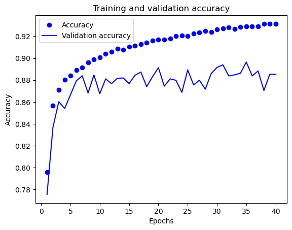

```python
plot_accuracy(results2.history['accuracy'], results2.history['val_accuracy'])
```

```python
test_loss, test_acc = overfit_network.evaluate(X_val, y_val)
```

## Dropout

```python
model_1 = models.Sequential()

model_1.add(layers.Dense(512, activation = 'relu'))
model_1.add(layers.Dropout(0.7))
model_1.add(layers.Dense(124, activation = 'relu'))
model_1.add(layers.Dense(46, activation = 'relu'))
model_1.add(layers.Dropout(0.7))
model_1.add(layers.Dense(10, activation = 'softmax'))
```

```python
model_1.compile(optimizer='adam',
                loss='categorical_crossentropy',
                metrics=['accuracy'])
```

```python
fit_1 = model_1.fit(X_train, y_train, epochs=40, batch_size= 128, validation_data=(X_val, y_val))
```

```python
model_1.summary()
```

```
Model: "sequential_9"
_________________________________________________________________
 Layer (type)                Output Shape              Param #
=================================================================
 dense_28 (Dense)            (None, 512)               401920

 dropout_5 (Dropout)         (None, 512)               0

 dense_29 (Dense)            (None, 124)               63612

 dense_30 (Dense)            (None, 46)                5750

 dropout_6 (Dropout)         (None, 46)                0

 dense_31 (Dense)            (None, 10)                470

=================================================================
Total params: 471752 (1.80 MB)
Trainable params: 471752 (1.80 MB)
Non-trainable params: 0 (0.00 Byte)
_________________________________________________________________
```

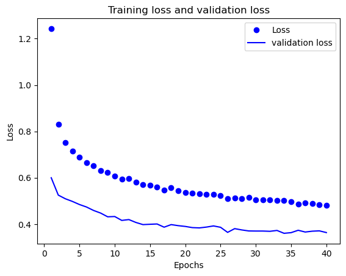

```python
plot_loss(fit_1.history['loss'], fit_1.history['val_loss'])
```

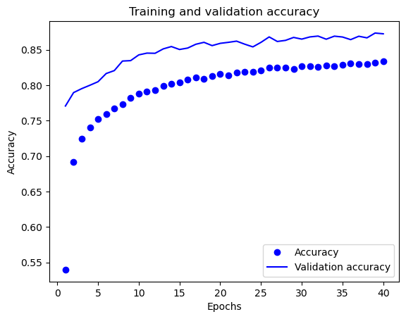

```python
plot_accuracy(fit_1.history['accuracy'], fit_1.history['val_accuracy'])
```

```python
test_loss, test_acc = model_1.evaluate(X_val, y_val)
```

## l1/l2 regularization

```python
model_2 = models.Sequential()
model_2.add(layers.Dense(512, activation = 'relu', input_shape = (28 * 28,)))
model_2.add(layers.Dense(124, kernel_regularizer=regularizers.l1(0.001), activation= 'relu', input_shape=(28 * 28,)))
model_2.add(layers.Dense(46, kernel_regularizer=regularizers.l2(0.001), activation= 'relu'))
model_2.add(layers.Dense(10, activation = 'softmax'))
```

```python
model_2.compile(optimizer = 'adam',
                loss='categorical_crossentropy',
                metrics=['accuracy'])
```

```python
fit_2 = model_2.fit(X_train, y_train, epochs=40, batch_size = 128, validation_data=(X_val, y_val))
```

```python
model_2.summary()
```

```
Model: "sequential_10"
_________________________________________________________________
 Layer (type)                Output Shape              Param #
=================================================================
 dense_32 (Dense)            (None, 512)               401920

 dense_33 (Dense)            (None, 124)               63612

 dense_34 (Dense)            (None, 46)                5750

 dense_35 (Dense)            (None, 10)                470

=================================================================
Total params: 471752 (1.80 MB)
Trainable params: 471752 (1.80 MB)
Non-trainable params: 0 (0.00 Byte)
_________________________________________________________________
```

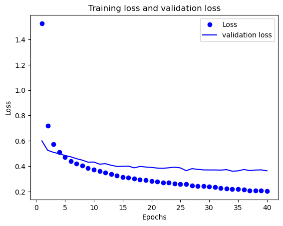

```python
plot_loss(fit_2.history['loss'], fit_1.history['val_loss'])
```

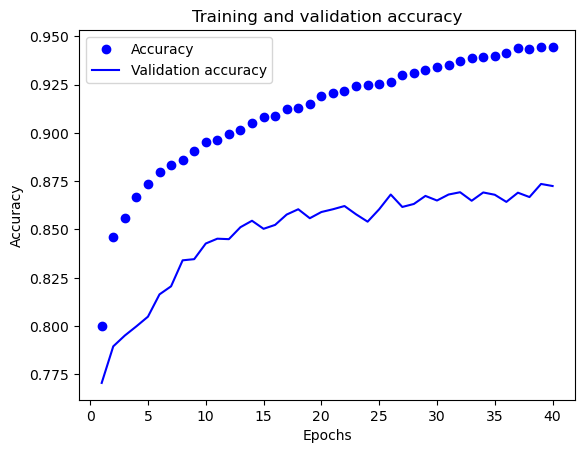

```python
plot_accuracy(fit_2.history['accuracy'], fit_1.history['val_accuracy'])
```

```python
test_loss, test_acc = model_2.evaluate(X_val, y_val)
```

```python
model_3 = models.Sequential()

model_3.add(layers.Dense(512, activation = 'relu', input_shape = (28 * 28, )))
model_3.add(layers.Dropout(0.7))
model_3.add(layers.Dense(124, kernel_regularizer=regularizers.l1(0.001), activation= 'relu', input_shape=(28 * 28,)))
model_3.add(layers.Dense(46, activation = 'relu'))
model_3.add(layers.Dense(10, activation = 'softmax'))
```

```python
model_3.compile(optimizer = 'adam',
                loss='categorical_crossentropy',
                metrics=['accuracy'])
```

```python
fit_3 = model_3.fit(X_train, y_train, epochs=40, batch_size = 128, validation_data=(X_val, y_val))
```

```python
model_3.summary()
```

```
Model: "sequential_11"
_________________________________________________________________
 Layer (type)                Output Shape              Param #
=================================================================
 dense_36 (Dense)            (None, 512)               401920

 dropout_7 (Dropout)         (None, 512)               0

 dense_37 (Dense)            (None, 124)               63612

 dense_38 (Dense)            (None, 46)                5750

 dense_39 (Dense)            (None, 10)                470

=================================================================
Total params: 471752 (1.80 MB)
Trainable params: 471752 (1.80 MB)
Non-trainable params: 0 (0.00 Byte)
_________________________________________________________________
```

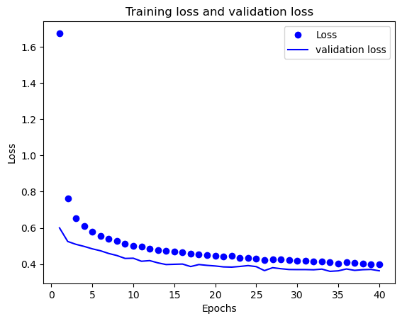

```python
plot_loss(fit_3.history['loss'], fit_1.history['val_loss'])
```

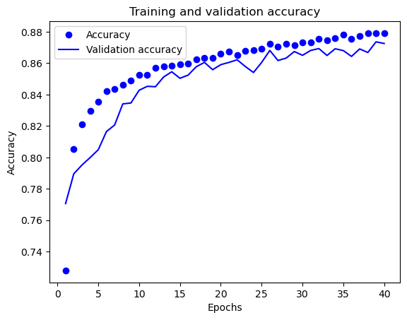

```python
plot_accuracy(fit_3.history['accuracy'], fit_1.history['val_accuracy'])
```

```python
test_loss, test_acc = model_3.evaluate(X_val, y_val)
```

## Final Model

```python
model_4 = models.Sequential()

model_4.add(layers.Dense(512, activation = 'relu', input_shape = (28 * 28, )))
model_4.add(layers.Dropout(0.7))
#model_4.add(layers.Dense(124, kernel_regularizer=regularizers.l1(0.001), activation= 'relu', input_shape=(28 * 28,)))
model_4.add(layers.Dense(46, activation = 'relu'))
model_4.add(layers.Dense(10, activation = 'softmax'))
```

```python
model_4.compile(optimizer = 'adam',
                loss='categorical_crossentropy',
                metrics=['accuracy'])
```

```python
fit_4 = model_4.fit(X_train, y_train, epochs=40, batch_size=64, validation_data=(X_val, y_val))
```

```python
model_4.summary()
```

```
Model: "sequential_12"
_________________________________________________________________
 Layer (type)                Output Shape              Param #
=================================================================
 dense_40 (Dense)            (None, 512)               401920

 dropout_8 (Dropout)         (None, 512)               0

 dense_41 (Dense)            (None, 46)                23598

 dense_42 (Dense)            (None, 10)                470

=================================================================
Total params: 425988 (1.63 MB)
Trainable params: 425988 (1.63 MB)
Non-trainable params: 0 (0.00 Byte)
_________________________________________________________________
```

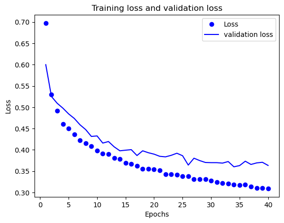

```python
plot_loss(fit_4.history['loss'], fit_1.history['val_loss'])
```

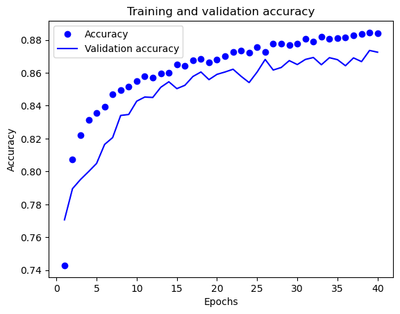

```python
plot_accuracy(fit_4.history['accuracy'], fit_1.history['val_accuracy'])
```

```python
test_loss, test_acc = model_4.evaluate(X_val, y_val)
```

```python
y_pred = model_4.predict(X_test)

y_test = np.argmax(y_test, axis = 1)
y_pred = np.argmax(y_pred, axis = 1)
```

```python
#evaluation metrics

cm = confusion_matrix(y_test, y_pred)
precison = precision_score(y_test, y_pred, average = 'micro')
recall = recall_score(y_test, y_pred, average = 'micro')
f1 = f1_score(y_test, y_pred, average = 'micro')
ck = cohen_kappa_score(y_test, y_pred)
```

```python
print("Precision:", precison)
print("Recall:", recall)
print("F1 Score:", f1)
print("Cohen Kappa:", ck)
```

```
Precision: 0.8922307753352908
Recall: 0.8922307753352908
F1 Score: 0.8922307753352908
Cohen Kappa: 0.880254930644194
```

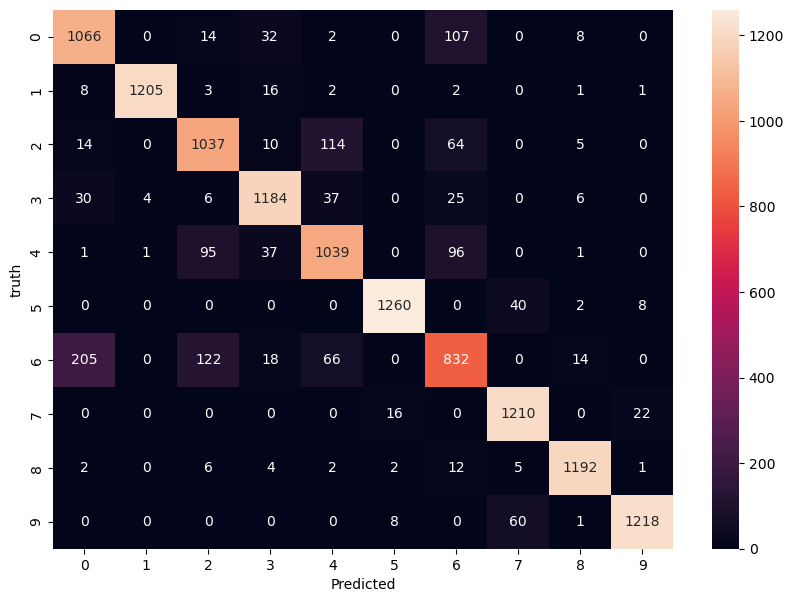

```python
import seaborn as sns

plt.figure(figsize = (10,7))
sns.heatmap(cm, annot = True, fmt = 'd')
plt.xlabel('Predicted')
plt.ylabel('truth')
```

```python
#comparing predicted and test split dataset value

print("Predicted values: ",y_pred[:5])
print("Test Dataset Values: ", y_test[:5])
```

```
Predicted values:  [1 3 3 3 9]
Test Dataset Values:  [1 3 3 3 9]
```

# 6. Conclusion

```
- overfit_network.add(layers.Dense(512, activation='relu', input_shape=(28 * 28,)))
- overfit_network.add(layers.Dense(124, activation = 'relu'))
- overfit_network.add(layers.Dense(46, activation = 'relu'))
- overfit_network.add(layers.Dense(10, activation = 'softmax'))
```

According to Chollet's DLWP we have to use softmax and categorical_crossentropy for last-layer activation. Also for the optimizer we will be using Adam as it works well for training deep learning models.

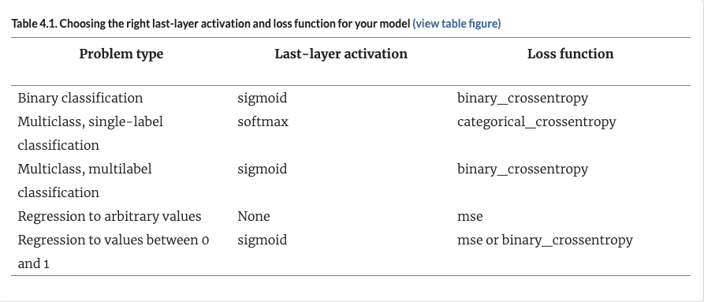

From the following evaluation metrics we can conclude that the model is rather accurate and has a precision score of 89.2%. By comparing the predicated y-values and y-test we can see that the model had predicted very accurately.